# Practical Machine Learning Project

Gwenaël Gouérou

May, 2015

# Abstract

This study is part of the *[Practical Machine Learning class on Coursera](https://www.coursera.org/course/predmachlearn)*. The goal of the project is to predict how well sport activity is done.  
Six participants using accelerometers on the belt, forearm, arm, and dumbell were asked to perform barbell lifts correctly and incorrectly in five different ways. The data come from this source : http://groupware.les.inf.puc-rio.br/har (see the section on the Weight Lifting Exercise Dataset).

The training and test data used for this project are available [here : train set](https://d396qusza40orc.cloudfront.net/predmachlearn/pml-training.csv) and [there : test set](https://d396qusza40orc.cloudfront.net/predmachlearn/pml-testing.csv).

After creating a prediction model of “how well did they did the exercise” (the “classe variable” in the training set), the machine learning algorithm will be applied to the 20 test cases available in the test set.

# Loading the data

When reading the data, the use of the argument `stringsAsFactors = FALSE` transforms automatically 37 columns from factor to character class. The NAs strings have been found after some exploratory data analysis (not reproduced here).

```r
## read the files
pml_training <- read.csv("pml-training.csv", stringsAsFactors = FALSE,
                         na.strings = c("NA", "", "#DIV/0!"))
pml_testing <- read.csv("pml-testing.csv", stringsAsFactors = FALSE,
                        na.strings = c("NA", "", "#DIV/0!"))
```

Unfortunately the classe column we’re interested in has also been converted to character. It’s imperative to convert it back to factor. This column being replaced by the problem_id column (see below) in the test set, there’s no problem there.

```r
c(names(pml_training)[160], names(pml_testing)[160])
```

```
## [1] "classe"     "problem_id"
```

```r
pml_training$classe <- as.factor(pml_training$classe)
unique(pml_training$classe)             ## the 5 classes of performance
```

```
## [1] A B C D E
## Levels: A B C D E
```

We can see that the training set is relatively homogeneously distributed in between the different ways of performing the barbell lifts :

```r
table(pml_training$classe)
```

```
##
##    A    B    C    D    E
## 5580 3797 3422 3216 3607
```

```r
classeTable <- table(pml_training$classe)
## show the proportion/percentage of each classe
prop.table(classeTable)   ## request a table as an argument
```

```
##
##         A         B         C         D         E
## 0.2843747 0.1935073 0.1743961 0.1638977 0.1838243
```

# Cleaning the Data

Now it’s time to clean the data. We can see that there is 17 kind of columns regarding the propotion of NAs values :

```r
unique(colMeans(is.na(pml_training)))
```

```
##  [1] 0.0000000 0.9798186 0.9809398 1.0000000 0.9797676 0.9793089 0.9832841
##  [8] 0.9833860 0.9798695 0.9832331 0.9795638 0.9794109 0.9795128 0.9793599
## [15] 0.9835898 0.9836408 0.9835389
```

One type of column has no missing values at all while the proportion in the columns containing missing values is always above 97%. With a so high percentage imputing the missing values would be useless. We’ll then remove those columns. We’ll remove also columns that don’t add to the prediction.

```r
dropNA <- names(pml_training[,(colMeans(is.na(pml_training)) >.97)])
drop2 <- names(pml_training[,grepl("^X|user_name|timestamp|window", names(pml_training))])

dropFINAL <- c(dropNA, drop2)

## keep only the columns not in the drop selection :
training <- pml_training[, !(names(pml_training) %in% dropFINAL)]
testing <- pml_testing[, !(names(pml_testing) %in% dropFINAL)]
```

**comparison of the dimensions before and after removing**

|  | rows before . | columns before . | rows after . | columns after |
| --- | --- | --- | --- | --- |
| training set | 19,622 | 160 | 19,622 | 53 |
| testing set | 20 | 160 | 20 | 53 |

# Splitting the data for cross-validation

Instead of using the build-in out-of-sample error in the functions, I prefered to create a validation set out of the training set, thus performing a two-fold cross-validation.

In this case, I used the myTraining set to create the model, the validation set to refine, and the test set was used only for predicting the 20 cases for the submission assignement of this class.

```r
library(caret) ; library(randomForest)
set.seed(2015)                  ## set the seed for reproducibility
inTrain <- createDataPartition(training$classe, p=0.7, list=FALSE)
myTraining <- training[inTrain,]
validation <- training[-inTrain,]
```

# Fitting the model

I tested six different models. The computation time ranges from 8 minutes to 12 hours ! While the accuracy ranges from 97,5% to 99,2%. The model I choose to present here is the fastest one (8 minutes) and gives the highest accuracy on the validation set (99,2%).

I focused my attention on the caret package as it was at the center of this class.

The key to reduce the computational time was to reduce the resampling parameter and the number of trees. For exemple, here I chose to create a random forest with only 5 repeats of the bootstrap resampling method, and 25 trees.

The key to maximize the accuracy was to prefer bootstrap resampling with replacement against K-fold cross-validation.

As I’m doing my own two-fold cross-validation with the validation set. The need to use the built-in K-fold method was reduced. It allows me the use of a second cross-validation method (bootstrapping) and thus improve the overall accuracy of the model.

I calculate my out-of-sample error based on my two-fold cross-validation.

I choose not to pre-process. In some of my models I use the principal component analysis (PCA) pre-processing, however this resulted in loss of accuracy of nearly two percent. Not doing may lead to overfitting, however as the number of repeats of bootstrap (five) and the number of trees(25) are small, I’m confident to have *avoided overfitting*, while with a quick computational time (I use a 2gb RAM computer), my model can *pass the scalability test* and be used on larger dataset.

```r
set.seed(2015)
control_Rf <- trainControl(method="boot", 5)       ## bootstrap 5 repeats
fit_Rf <- train(myTraining$classe ~ ., data=(myTraining), method="rf",
                trControl=control_Rf, ntree=25)
```

```
## Time difference of 8 mins
```

# Cross-validating on the validation set

In order to verify the accuracy of the model, I test it against the validation set :

```r
predictVAL <- predict(fit_Rf, validation)
confusionMatrix(validation$classe, predictVAL)
```

```
## Confusion Matrix and Statistics
##
##           Reference
## Prediction    A    B    C    D    E
##          A 1670    2    1    0    1
##          B    9 1125    5    0    0
##          C    0    7 1013    6    0
##          D    0    0    6  958    0
##          E    0    1    5    3 1073
##
## Overall Statistics
##
##                Accuracy : 0.9922
##                  95% CI : (0.9896, 0.9943)
##     No Information Rate : 0.2853
##     P-Value [Acc > NIR] : < 2.2e-16
##
##                   Kappa : 0.9901
##  Mcnemar's Test P-Value : NA
##
## Statistics by Class:
##
##                      Class: A Class: B Class: C Class: D Class: E
## Sensitivity            0.9946   0.9912   0.9835   0.9907   0.9991
## Specificity            0.9990   0.9971   0.9973   0.9988   0.9981
## Pos Pred Value         0.9976   0.9877   0.9873   0.9938   0.9917
## Neg Pred Value         0.9979   0.9979   0.9965   0.9982   0.9998
## Prevalence             0.2853   0.1929   0.1750   0.1643   0.1825
## Detection Rate         0.2838   0.1912   0.1721   0.1628   0.1823
## Detection Prevalence   0.2845   0.1935   0.1743   0.1638   0.1839
## Balanced Accuracy      0.9968   0.9941   0.9904   0.9947   0.9986
```

```r
modelAcc <- round(confusionMatrix(validation$classe, predictVAL)$overall[[1]],4)*100
## modelAcc will be used as an embedded R code in the next line.
```

**The accuracy is 99.22%, so the out-of-sample error is** **0.78 %.**

As we can see that my out-of-sample error is close to the one calculated by the built-in function :

```r
fit_Rf$finalModel$err.rate[25,1]
```

```
##        OOB
## 0.01332169
```

# Predicting on the test set

The machine learning algorithm is now to be applied to the 20 cases of the test set.

```r
predict(fit_Rf, testing)
```

```
##  [1] B A B A A E D B A A B C B A E E A B B B
## Levels: A B C D E
```

Number of correct predictions : 20 out of 20.

# Appendix

```r
fit_Rf
```

```
## Random Forest
##
## 13737 samples
##    52 predictor
##     5 classes: 'A', 'B', 'C', 'D', 'E'
##
## No pre-processing
## Resampling: Bootstrapped (5 reps)
##
## Summary of sample sizes: 13737, 13737, 13737, 13737, 13737
##
## Resampling results across tuning parameters:
##
##   mtry  Accuracy   Kappa      Accuracy SD  Kappa SD
##    2    0.9847074  0.9806373  0.003364473  0.004258543
##   27    0.9868852  0.9833952  0.002310215  0.002926653
##   52    0.9827078  0.9781098  0.001781387  0.002241102
##
## Accuracy was used to select the optimal model using  the largest value.
## The final value used for the model was mtry = 27.
```

```r
fit_Rf$finalModel
```

```
##
## Call:
##  randomForest(x = x, y = y, ntree = 25, mtry = param$mtry)
##                Type of random forest: classification
##                      Number of trees: 25
## No. of variables tried at each split: 27
##
##         OOB estimate of  error rate: 1.33%
## Confusion matrix:
##      A    B    C    D    E class.error
## A 3894    9    3    0    0 0.003072197
## B   30 2604   18    2    4 0.020316027
## C    1   27 2355   11    2 0.017111853
## D    0    1   44 2204    3 0.021314387
## E    1    5   11   11 2497 0.011089109
```

```r
varImp(fit_Rf)
```

```
## rf variable importance
##
##   only 20 most important variables shown (out of 52)
##
##                      Overall
## roll_belt            100.000
## pitch_forearm         54.009
## yaw_belt              44.150
## magnet_dumbbell_z     43.537
## roll_forearm          42.417
## magnet_dumbbell_y     42.056
## pitch_belt            42.031
## accel_dumbbell_y      22.035
## accel_forearm_x       16.878
## magnet_dumbbell_x     15.595
## magnet_forearm_z      15.159
## magnet_belt_z         14.875
## roll_dumbbell         14.388
## accel_dumbbell_z      12.154
## magnet_belt_y         11.148
## total_accel_dumbbell  11.052
## roll_arm              10.046
## gyros_belt_z           9.954
## accel_forearm_z        9.675
## yaw_arm                9.261
```

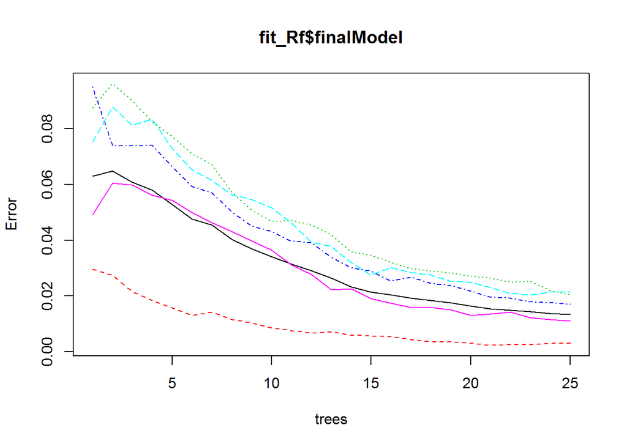

```r
plot(fit_Rf$finalModel)
```

# References

- Velloso, E.; Bulling, A.; Gellersen, H.; Ugulino, W.; Fuks, H. [Qualitative Activity Recognition of Weight Lifting Exercises](http://groupware.les.inf.puc-rio.br/work.jsf?p1=11201). Proceedings of 4th International Conference in Cooperation with SIGCHI (Augmented Human ’13) . Stuttgart, Germany: ACM SIGCHI, 2013. [Read more](http://groupware.les.inf.puc-rio.br/har#ixzz3afJgK17S) / [Documento](http://groupware.les.inf.puc-rio.br/public/papers/2013.Velloso.QAR-WLE.pdf]).
- Hlavac, Marek (2014). stargazer: LaTeX code and ASCII text for well-formatted regression and summary statistics tables. R package version 5.1. http://CRAN.R-project.org/package=stargazer